# Lecture 501 Exploratory analysis

[figure not shown]

2020-01-15

## Recap @ 501

## Previous lectures

- What is reproducible data analysis?
  - why is it important?
  - software engineering
  - practical principles
- Tools
  - Markdown
  - RMarkdown
  - Git

## This lecture

- Data visualisation
  - histograms
  - boxplots
  - scatterplots
- Descriptive statistics
- Exploring assumptions
  - Shapiro–Wilk test
  - skewness and kurtosis
  - Levene’s test

## Data visualisation

## Visual variables

A **visual variable** is an aspect of a **mark** that can be controlled to change its appearance.

Visual variables include:

- Size
- Shape
- Orientation
- Colour (hue)
- Colour value (brightness)
- Texture
- Position (2 dimensions)

## Grammar of graphics

Grammars provide rules for languages

*“The grammar of graphics takes us beyond a limited set of charts (words) to an almost unlimited world of graphical forms (statements)”* (Wilkinson, 2005)

Statistical graphic specifications are expressed in six statements:

1. **Data** manipulation
2. **Variable** transformations (e.g., rank),
3. **Scale** transformations (e.g., log),
4. **Coordinate system** transformations (e.g., polar),
5. **Element**: mark (e.g., points) and visual variables (e.g., color)
6. **Guides** (axes, legends, etc.).

## ggplot2

The `ggplot2` library offers a series of functions for creating graphics **declaratively**, based on the Grammar of Graphics.

To create a graph in `ggplot2`:

- provide the data
- specify elements
  - which visual variables (`aes`)
  - which marks (e.g., `geom_point`)
- apply transformations
- guides

```r
library(tidyverse)
library(nycflights13)
library(knitr)
```

## Histograms

- `x` variable to plot
- `geom_histogram`

```r
nycflights13::flights %>%
  filter(month == 11) %>%
  ggplot(
    aes(
      x = dep_delay
    )
  ) +
  geom_histogram(
    binwidth = 10
  )
```

## Histograms

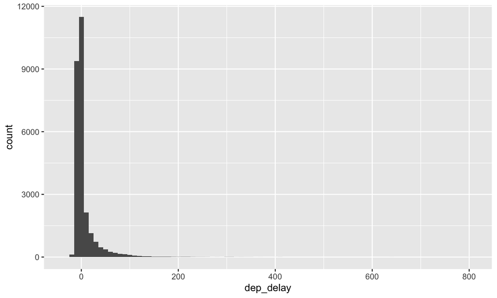

## Boxplots

- `x` categorical variable
- `y` variable to plot
- `geom_boxplot`

```r
nycflights13::flights %>%
  filter(month == 11) %>%
  ggplot(
    aes(
      x = carrier,
      y = arr_delay
    )
  ) +
  geom_boxplot()
```

## Boxplots

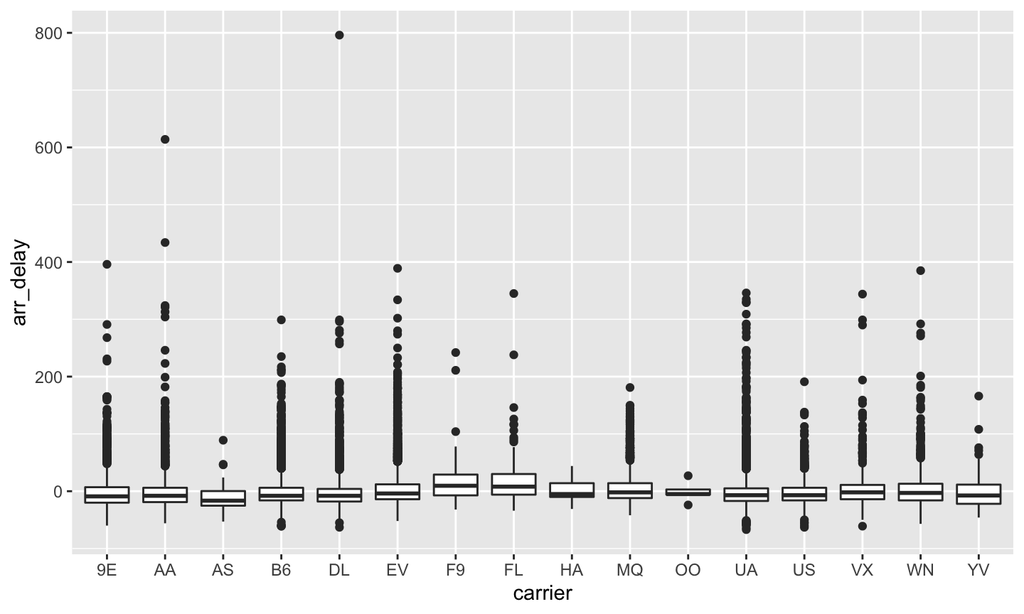

## Jittered points

- `x` categorical variable
- `y` variable to plot
- `geom_jitter`

```r
nycflights13::flights %>%
  filter(month == 11) %>%
  ggplot(
    aes(
      x = carrier,
      y = arr_delay
    )
  ) +
  geom_jitter()
```

## Jittered points

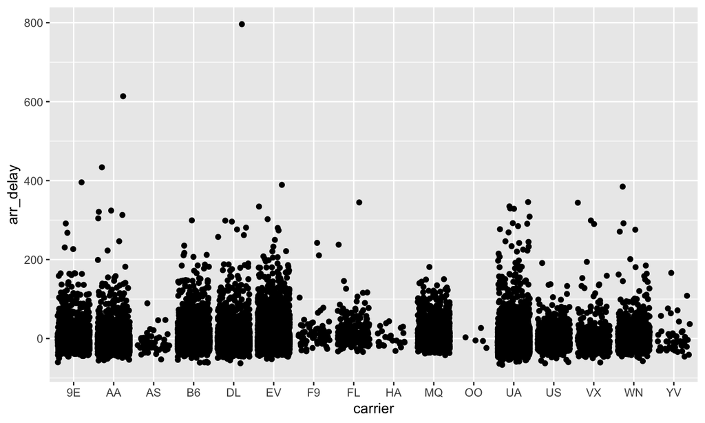

## Violin plot

- `x` categorical variable
- `y` variable to plot
- `geom_violin`

```r
nycflights13::flights %>%
  filter(month == 11) %>%
  ggplot(
    aes(
      x = carrier,
      y = arr_delay
    )
  ) +
  geom_violin()
```

## Violin plot

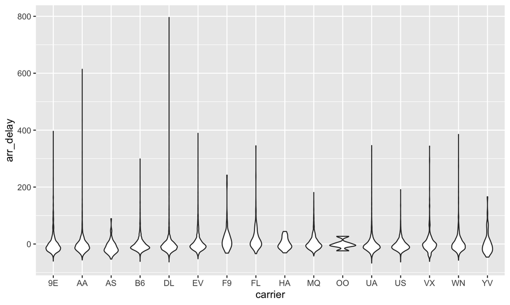

## Lines

- `x` e.g., a temporal variable
- `y` variable to plot
- `geom_line`

```r
nycflights13::flights %>%
  filter(!is.na(dep_delay)) %>%
  mutate(flight_date = ISOdate(year, month, day)) %>%
  group_by(flight_date) %>%
  summarize(avg_dep_delay = mean(dep_delay)) %>%
  ggplot(aes(
    x = flight_date,
    y = avg_dep_delay
  )) +
  geom_line()
```

## Lines

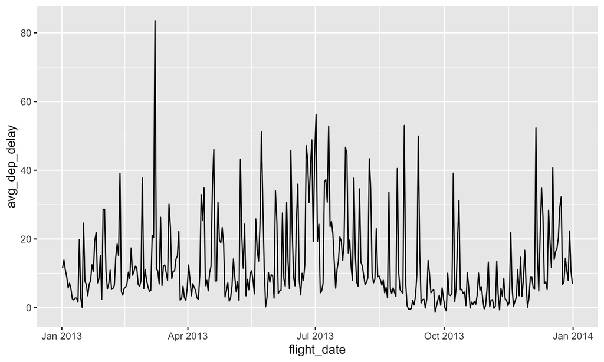

## Scatterplots

- `x` and `y` variable to plot
- `geom_point`

```r
nycflights13::flights %>%
  filter(
    month == 11,
    carrier == "US",
    !is.na(dep_delay),
    !is.na(arr_delay)
  ) %>%
  ggplot(aes(
    x = dep_delay,
    y = arr_delay
  )) +
  geom_point()
```

## Scatterplots

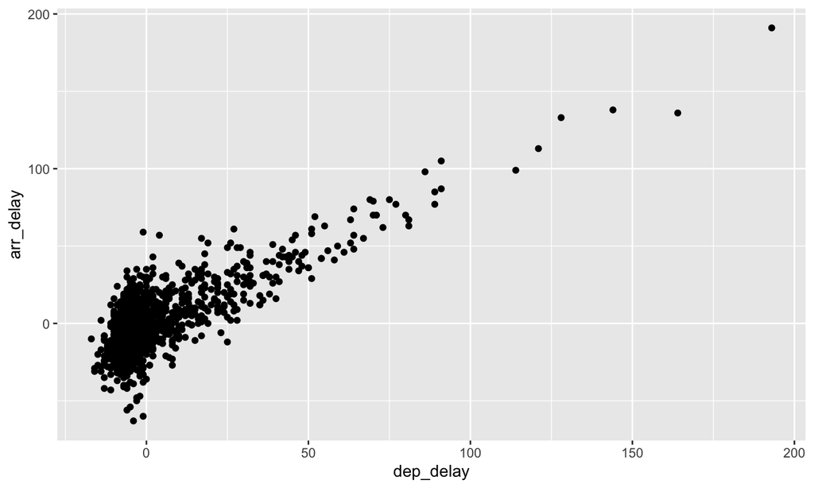

## Overlapping points

- `x` and `y` variable to plot
- `geom_count` counts overlapping points and maps the count to size

```r
nycflights13::flights %>%
  filter(
    month == 11, carrier == "US",
    !is.na(dep_delay), !is.na(arr_delay)
  ) %>%
  ggplot(aes(
    x = dep_delay,
    y = arr_delay
  )) +
  geom_count()
```

## Overlapping points

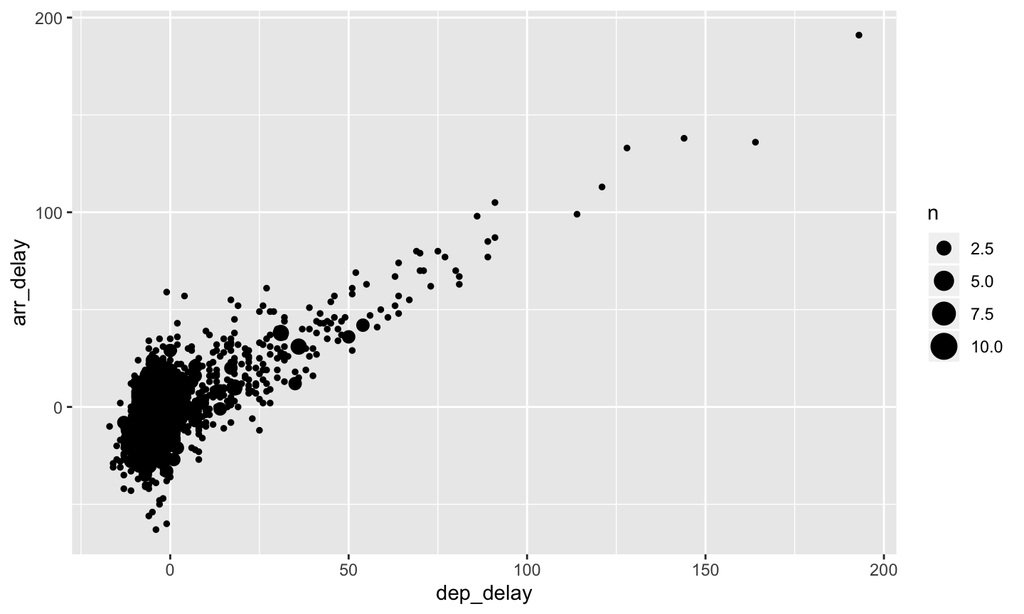

## Bin counts

- `x` and `y` variable to plot
- `geom_bin2d`

```r
nycflights13::flights %>%
  filter(
    month == 11,
    carrier == "US",
    !is.na(dep_delay),
    !is.na(arr_delay)
  ) %>%
  ggplot(aes(
    x = dep_delay,
    y = arr_delay
  )) +
  geom_bin2d()
```

## Bin counts

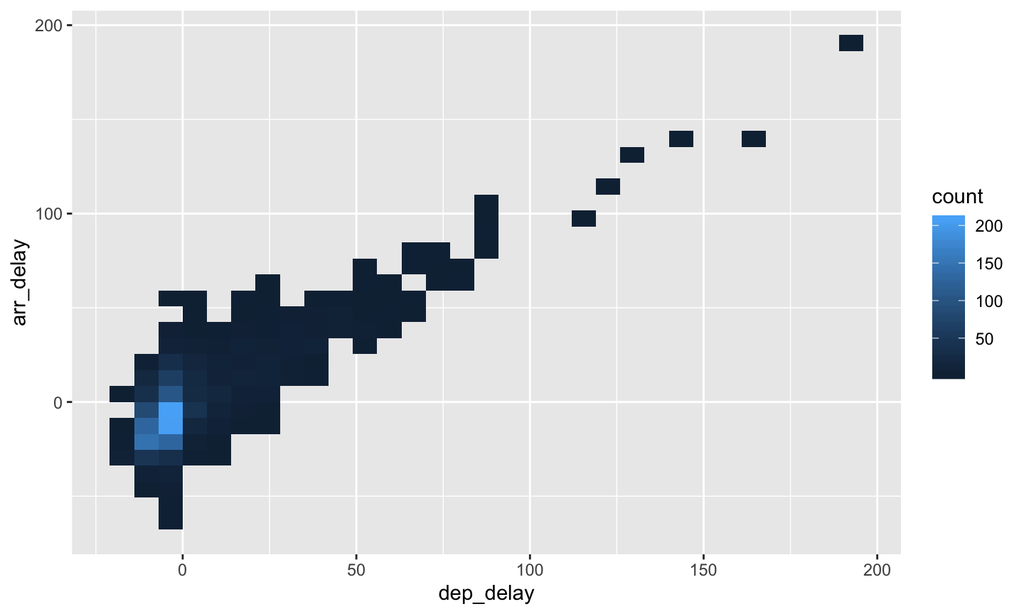

## Descriptive statistics

## Descriptive statistics

Quantitatively describe or summarize variables

- `stat.desc` from `pastecs` library
  - `base` includes counts
  - `desc` includes descriptive stats
  - `norm` (default is `FALSE`) includes distribution stats

```r
library(pastecs)

nycflights13::flights %>%
  filter(month == 11, carrier == "US") %>%
  select(dep_delay, arr_delay, distance) %>%
  stat.desc() %>%
  kable()
```

## stat.desc output

|  | dep_delay | arr_delay | distance |
| --- | --- | --- | --- |
| nbr.val | 1668.0000000 | 1667.000000 | 1.699000e+03 |
| nbr.null | 58.0000000 | 35.000000 | 0.000000e+00 |
| nbr.na | 31.0000000 | 32.000000 | 0.000000e+00 |
| min | -17.0000000 | -63.000000 | 9.600000e+01 |
| max | 193.0000000 | 191.000000 | 2.153000e+03 |
| range | 210.0000000 | 254.000000 | 2.057000e+03 |
| sum | 961.0000000 | -4450.000000 | 9.715580e+05 |
| median | -4.0000000 | -7.000000 | 5.290000e+02 |
| mean | 0.5761391 | -2.669466 | 5.718411e+02 |
| SE.mean | 0.4084206 | 0.518816 | 1.464965e+01 |
| CI.mean.0.95 | 0.8010713 | 1.017600 | 2.873327e+01 |
| var | 278.2347513 | 448.706408 | 3.646264e+05 |
| std.dev | 16.6803702 | 21.182691 | 6.038430e+02 |
| coef.var | 28.9519850 | -7.935179 | 1.055963e+00 |

## stat.desc: basic

- `nbr.val`: overall number of values in the dataset
- `nbr.null`: number of `NULL` values – NULL is often returned by expressions and functions whose values are undefined
- `nbr.na`: number of `NA`s – missing value indicator

## stat.desc: desc

- `min` (also `min()`): **minimum** value in the dataset
- `max` (also `max()`): **minimum** value in the dataset
- `range`: difference between `min` and `max` (different from `range()`)
- `sum` (also `sum()`): sum of the values in the dataset
- `mean` (also `mean()`): **arithmetic mean**, that is `sum` over the number of values not `NA`
- `median` (also `median()`): **median**, that is the value separating the higher half from the lower half the values
- `mode()`functio is available: **mode**, the value that appears most often in the values

## Sample statistics

Assuming that the data in the dataset are a sample of a population

- `SE.mean`: **standard error of the mean** – estimation of the variability of the mean calculated on different samples of the data (see also *central limit theorem*)
- `CI.mean.0.95`: **95% confidence interval of the mean** – indicates that there is a 95% probability that the actual mean is within that distance from the sample mean

## Estimating variation

- `var`: **variance** (\(\sigma^2\)), it quantifies the amount of variation as the average of squared distances from the mean

\[\sigma^2 = \frac{1}{n} \sum_{i=1}^n (\mu-x_i)^2\]

- `std.dev`: **standard deviation** (\(\sigma\)), it quantifies the amount of variation as the square root of the variance

\[\sigma = \sqrt{\frac{1}{n} \sum_{i=1}^n (\mu-x_i)^2}\]

- `coef.var`: **variation coefficient** it quantifies the amount of variation as the standard deviation divided by the mean

## Exploring assumptions

## Normal distribution

- characterized by the bell-shaped curve
- majority of values lie around the centre of the distribution
- the further the values are from the centre, the lower their frequency
- about 95% of values within 2 standard deviations from the mean

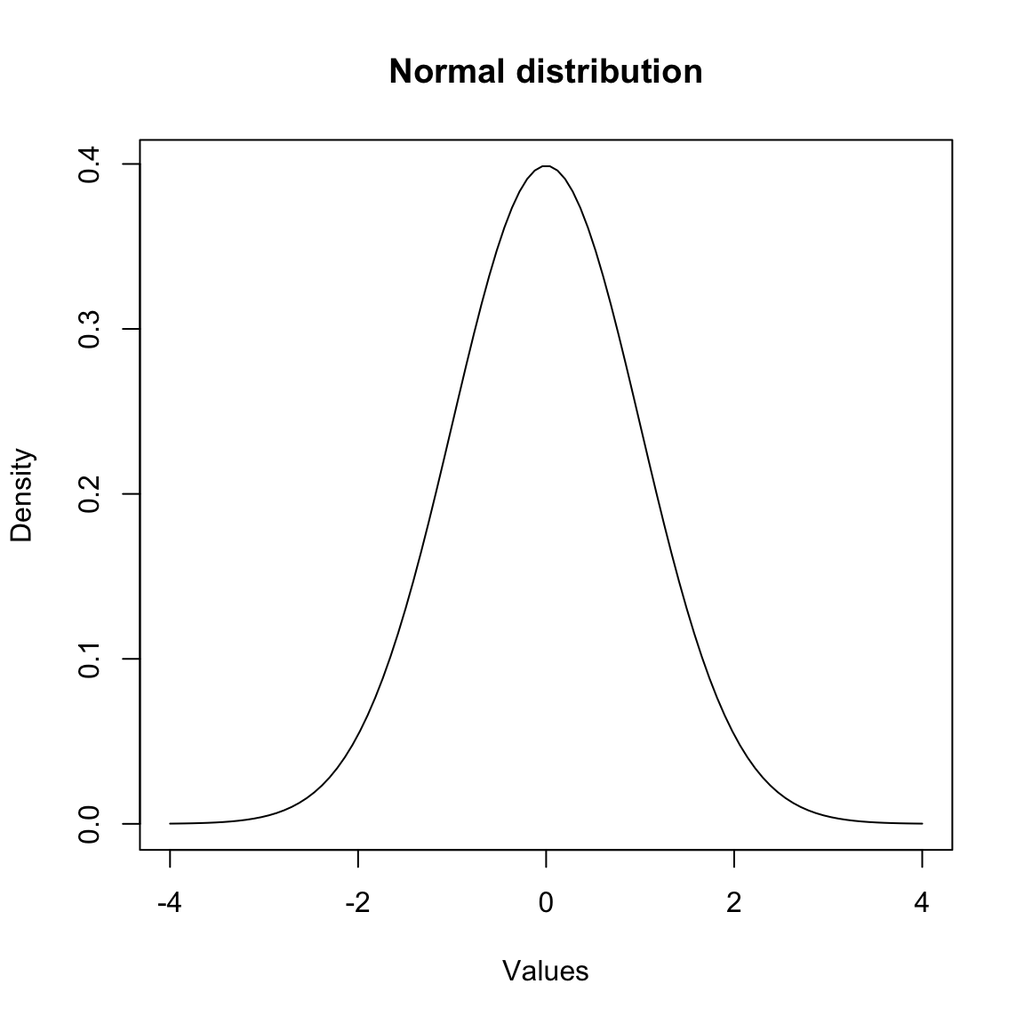

## Density histogram

[figure not shown]

```r
nycflights13::flights %>%
  ggplot(
    aes(
      x = dep_delay
    )
  ) +
  geom_histogram(
    aes(
      y =..density..
    ),
    binwidth = 10
  ) +
  stat_function(
    fun = dnorm,
    args = list(
      mean = dep_delay_mean,
      sd = dep_delay_sd),
    colour = "black", size = 1)
```

## Q-Q plot

Cumulative values against the cumulative probability of a particular distribution

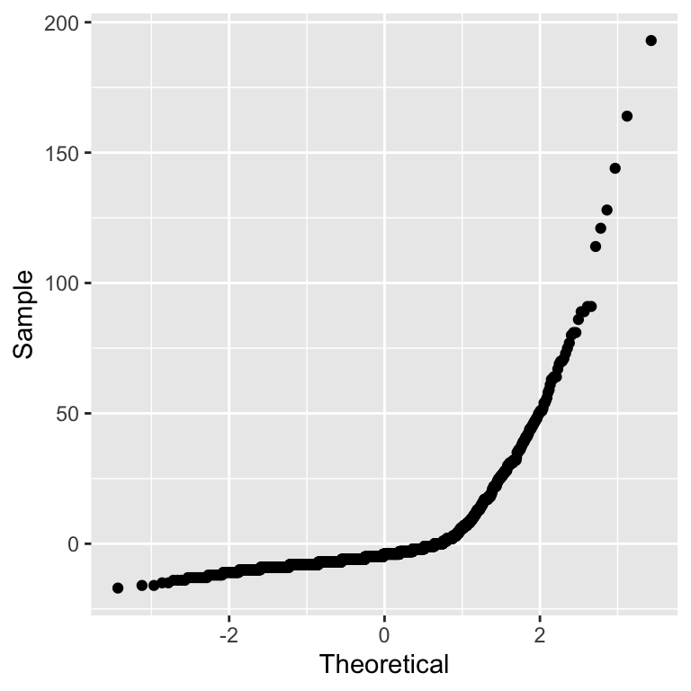

```r
nycflights13::flights %>%
  filter(
    month == 11,
    carrier == "US"
  ) %>%
  qplot(
    sample = dep_delay,
    data = .,
    stat = "qq",
    xlab = "Theoretical",
    ylab = "Sample"
  )
```

## stat.desc: norm

```r
nycflights13::flights %>%
  filter(month == 11, carrier == "US") %>%
  select(dep_delay, arr_delay, distance) %>%
  stat.desc(basic = FALSE, desc = FALSE, norm = TRUE) %>%
  kable()
```

|  | dep_delay | arr_delay | distance |
| --- | --- | --- | --- |
| skewness | 4.4187763 | 2.0716291 | 2.0030249 |
| skew.2SE | 36.8709612 | 17.2808242 | 16.8678747 |
| kurtosis | 28.8513206 | 9.5741004 | 2.6000743 |
| kurt.2SE | 120.4418092 | 39.9557893 | 10.9542887 |
| normtest.W | 0.5545326 | 0.8657894 | 0.6012442 |
| normtest.p | 0.0000000 | 0.0000000 | 0.0000000 |

## Normality

**Shapiro–Wilk test** compares the distribution of a variable with a normal distribution having same mean and standard deviation

- If significant, the distribution is not normal
- `normtest.W` (test statistics) and `normtest.p` (significance)
- also, `shapiro.test` function is available

```r
nycflights13::flights %>%
  filter(month == 11, carrier == "US") %>%
  pull(dep_delay) %>%
  shapiro.test()
```

```
##
##  Shapiro-Wilk normality test
##
## data:  .
## W = 0.55453, p-value < 2.2e-16
```

## Significance

Most statistical tests are based on the idea of hypothesis testing

- a **null hypothesis** is set
- the data are fit into a statistical model
- the model is assessed with a **test statistic**
- the **significance** is the probability of obtaining that test statistic value by chance

The threshold to accept or reject an hypotheis is arbitrary and based on conventions (e.g., *p < .01* or *p < .05*)

**Example:** The null hypotheis of the Shapiro–Wilk test is that the sample is normally distributed and *p < .01* indicates that the probability of that being true is very low.

## Skewness and kurtosis

In a normal distribution, the values of *skewness* and *kurtosis* should be zero

- `skewness`: **skewness** value indicates
  - positive: the distribution is skewed towards the left
  - negative: the distribution is skewed towards the right
- `kurtosis`: **kurtosis** value indicates
  - positive: heavy-tailed distribution
  - negative: flat distribution
- `skew.2SE` and `kurt.2SE`: skewness and kurtosis divided by 2 standard errors. If greater than 1, the respective statistics is significant (*p < .05*).

## Homogeneity of variance

**Levene’s test** for equality of variance in different levels

- If significant, the variance is different in different levels

```r
dep_delay_carrier <- nycflights13::flights %>%
  filter(month == 11) %>%
  select(dep_delay, carrier)

library(car)
leveneTest(dep_delay_carrier$dep_delay, dep_delay_carrier$carrier)
```

```
## Levene's Test for Homogeneity of Variance (center = median)
##          Df F value    Pr(>F)
## group    15  20.203 < 2.2e-16 ***
##       27019
## ---
## Signif. codes:  0 '***' 0.001 '**' 0.01 '*' 0.05 '.' 0.1 ' ' 1
```

## Summary

## Summary

- Data visualisation
  - histograms
  - boxplots
  - scatterplots
- Descriptive statistics
- Exploring assumptions
  - Shapiro–Wilk test
  - skewness and kurtosis
  - Levene’s test

## Practical session

In the practical session, we will see:

- Data visualisation
  - histograms
  - boxplots
  - scatterplots
- Descriptive statistics
- Exploring assumptions
  - Shapiro–Wilk test
  - skewness and kurtosis
  - Levene’s test

## Next lecture

- Comparing means
  - t-test
  - ANOVA
- Correlation
  - Pearson’s r
  - Spearman’s rho
  - Kendall’s tau
- Regression
  - univariate